# Metody pomiaru VaR

Magdalena Marecik

7 01 2022

##### Kod w R: [link](https://github.com/mmarecik/VaR-single-asset-portfolio/blob/main/code.R)

## 1. Wprowadzenie

W pracy dokonano pomiarów ryzyka rynkowego dla 3 wybranych europejskich indeksów giełdowych - warszawskiego WIG, niemieckiego DAX oraz szwajcarskiego SIM. Głównym celem projektu było wyznaczenie ryzyka za pomoca miary Value at Risk oraz ES (warunkowego VaR) z wykorzystaniem kilku technik oraz porównanie, która z nich w danym przypadku sprawdziła się najlepiej.

## 2. Analiza

### Wykresy cen zamknięcia

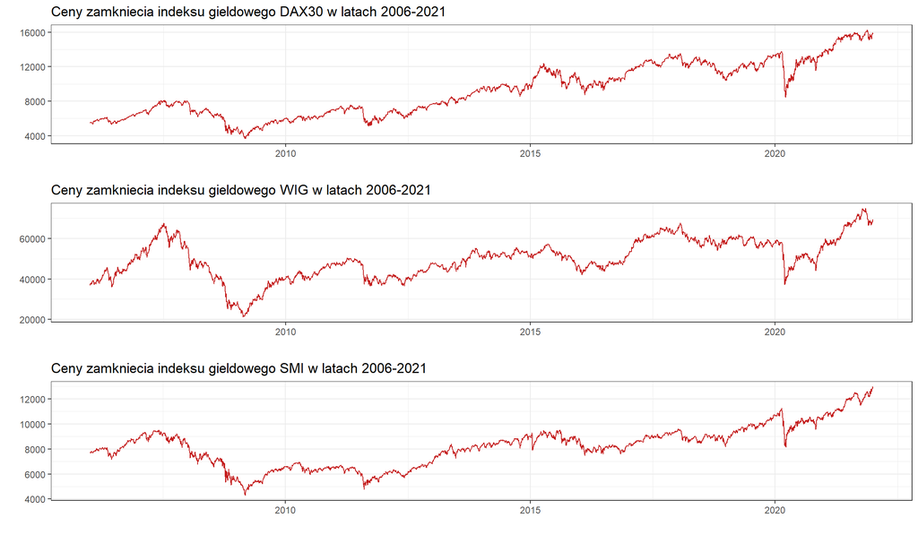

### Wykresy logarytmicznych stop zwrotu wybranych indeksow gieldowych

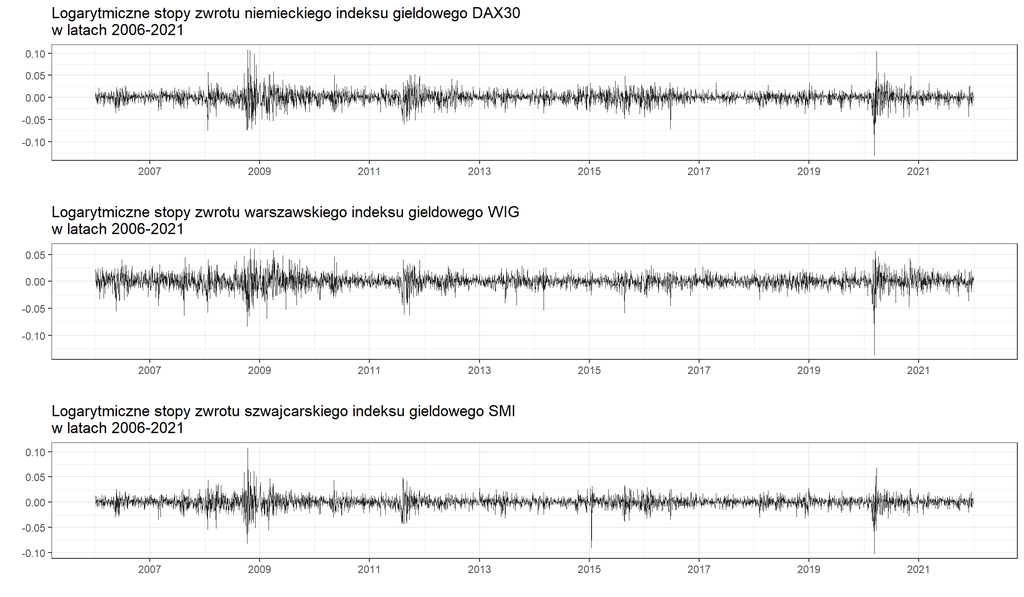

Na wykresach stóp zwrotu możemy dostrzec charakterystyczny efekt skupiania (gromadzenia) zmienności (volatility clustering). Zarówno małe, jak i duże zmiany kursu następują seriami. Świadczy to o heteroskedastyczności wariancji stóp zwrotu w czasie. Największe wahania stóp zwrotu możemy zaobserwować w dwóch okresach - w latach 2007 do 2009, kiedy miał miejsce ogólnoświatowy kryzys gospodarczy, a także na początku roku 2020, gdy rozpoczęła się pandemia COVID-19. Można dostrzec także, że w przypadku każdego z 3 indeksów skupiska zmienności stóp zwrotu występują w podobnych okresach, zatem kształtowały je w głównej mierze czynniki globalne, gdyż każdy indeks pochodzi z innego kraju.

### Statystyki opisowe

| Indeks | Średnia | Odchylenie | Max | Min | Kurtoza | Skośność |
| --- | --- | --- | --- | --- | --- | --- |
| DAX | 0.0002637 | 0.0137075 | 0.1079747 | -0.1305486 | 8.252042 | -0.2393029 |
| WIG | 0.0001634 | 0.0124791 | 0.0608344 | -0.1352654 | 7.135933 | -0.7453757 |
| SMI | 0.0001303 | 0.0110855 | 0.1078760 | -0.1013394 | 9.693297 | -0.4176051 |

Średnia stóp zwrotu minimalnie powyżej zera świadczy o niewielkim trendzie wzrostowym stóp zwrotu w dłuższym okresie czasu. Odchylenie standardowe stóp zwrotu badanych indeksów wynosi około 0.01. Dla indeksu WIG obserwujemy najmniejszą wartość maksymalna oraz najmniejszą wartość minimalną stóp zwrotu spośród wszystkich wartości stóp zwrotu w badanym okresie. Empiryczny rozkład badanych stóp zwrotu na stosunkowo dużą kurtozę, co świadczy o skoncentrowaniu stóp zwrotu wokół średniej i prawdopodobieństwie wystąpienia nietypowych zmian kursu (stóp zwrotu co do wartości bezwzględnej) większym niż w rozkładzie normalnym. Kurtoza dla badanych stóp zwrotu jest większa od 3, zatem rozkłady nie są rozkładami normalnymi. W przypadku wszystkich trzech indeksów obserwujemy skośność lewostronną.

### Rozkład stóp zwrotu

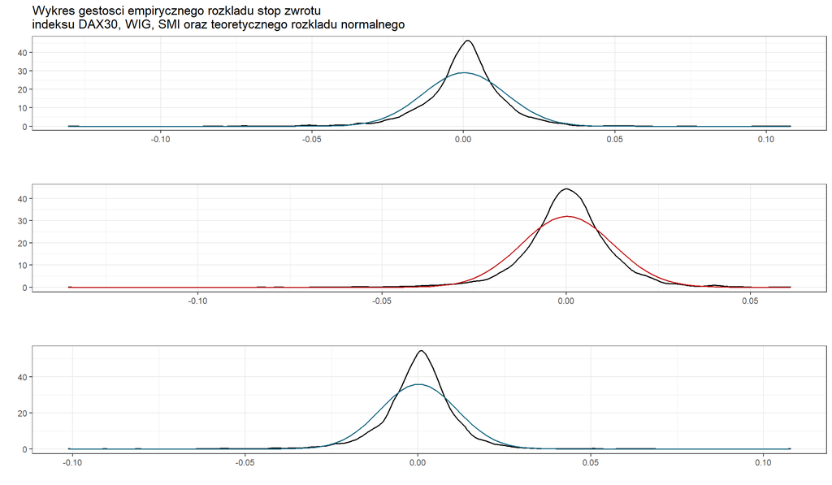

Wykresy gęstosci stóp zwrotu wybranych indeksów giełdowych potwierdzają powyższe statystyki. Widzimy, że stopy zwrotu nie są dobrze opisywane rozkłądem normalnych ze względu na występowanie grubszych ogonów, większej liczby zwrotów bliskich średniej oraz mniejszej liczby zmian przeciętnych.

Dla wszystkich trzech indeksów wykonano testy zgodności Andersona-Darlina z rozkładem normalnym, t-studenta, logicznym oraz alfa-stabilnym. W przypadku indeksu WIG oraz SMI nie było podstaw do odrzucenia hipotezy zerowej stanowiącej o tym, że ich stopy zwrotu mają rozkład stabilny.

```
##
##  Anderson-Darling test of goodness-of-fit
##  Null hypothesis: distribution 'pstable'
##  Parameters assumed to be fixed
##
## data:  wig$st.zwrotu
## An = 1.3548, p-value = 0.2153
```

## 3. Pomiar ryzyka rynkowego

W dalszej części, na podstawie 250-dniowej historii stóp zworotu indeksów giełdowych DAX, WIG oraz SMI, zostanie wyznaczona 95% oraz 99% wartość narażona na ryzyko (VaR) oraz 95% i 99% warunkowa wartość narażona na ryzyko (ES) z wykorzystaniem nastepujacych technik:

1. Metoda symulacji historycznych
2. Metoda symulacji historycznych z wagami
3. Metoda o zmieniającej się zmienności w czasie - EWMA
4. Metoda o zmieniającej się zmienności w czasie - GARCH(1,1)

Value at Risk to maksymalna kwota, jaką można stracić w wyniku inwestycji w portfel o określonym horyzoncie czasowym i przy założonym poziomie istotności. Warunkową wartość zagrożoną możemy zdefiniować jako wartość oczekiwaną straty pod warunkiem, że strata ta przekroczy wartość zagrożoną odpowiadającą zadanemu poziomowi ufności.

### Metoda symulacji historycznych

Metoda symulacji historycznej jest jedną z najprostszych i najbardziej zrozumiałych metod obliczania wartości zagrożonej. Metoda ta polega na wykorzystaniu danych historycznych, którymi są historyczne stopy zwrotu analizowanego instrumentu finansowego. Historyczne stopy zwrotu umożliwiają określenie empirycznego rozkładu stóp zwrotu. To pozwala na określenie wartości VaR poprzez wyznaczenie kwantyla tego rozkładu (Jajuga K., “Zarządzanie ryzykiem”).

Warunkiem koniecznym, aby symulacja historyczna była skuteczna, jest załozenie o niezmienności stóp zwrotu w stosunku do danych historycznych.

### Metoda symulacji historycznych z wagami

W metodzie symulacji historycznych z wagami zakładamy, że im starszy dany scenariusz, tym mniejsze prawdopodobienstwo, że ta sama stopa zwrotu powtórzy się w aktualnym scenariuszu. Prawdopodobieństwa (wagi) kolejnych scenariuszy maleją wykładniczo i są wyznaczane wg ponizszego wzoru:

$$p_i=\frac{q^{n−i}(1−q)}{1−q^n}$$

Ponizej ukazano wykresy VaR oraz ES wyestymowanych metoda symulacji historycznej oraz symulacji historycznej z wagami.

#### DAX30

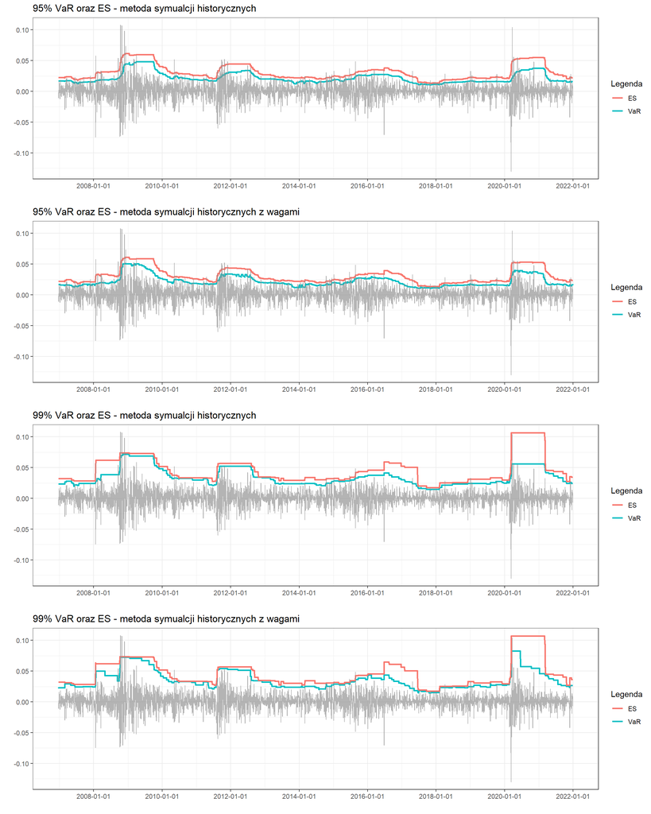

#### WIG

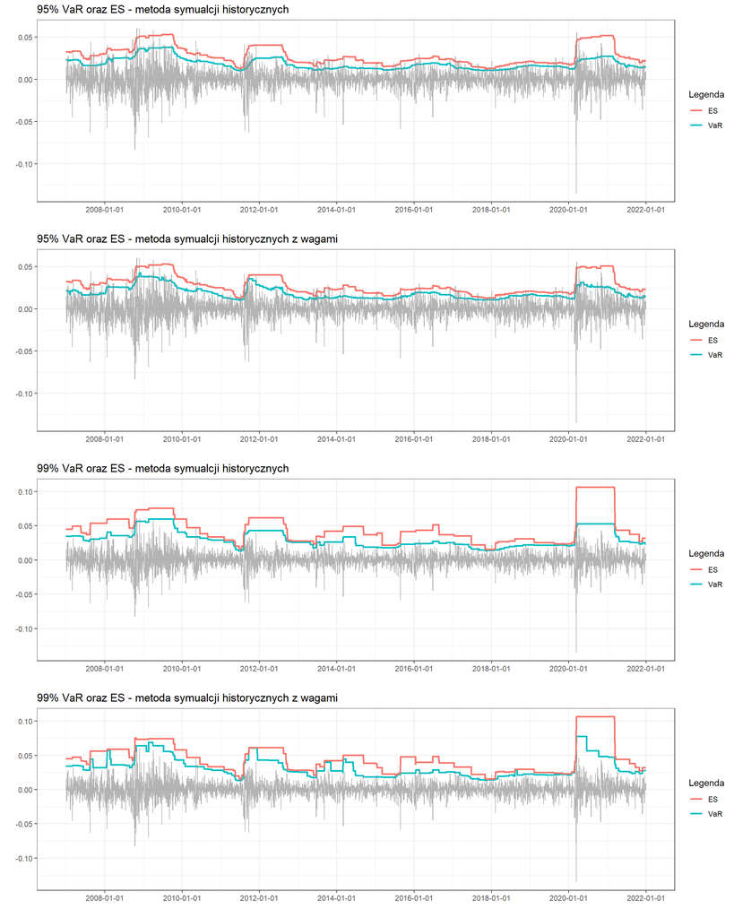

#### SMI

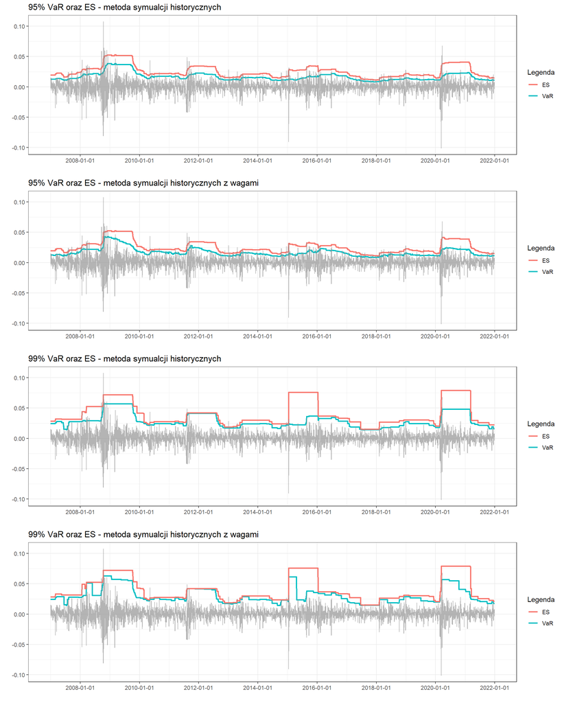

### Metoda EWMA

W modelach klasy EWMA wartość warunkowej wariancji szacowana jest jako ważona wykładniczo średnia jej poprzednich wartości. Podejście to umożliwia uwzględnienie aktualności danych dotyczących warunkowej wariancji. Ważenie wykładnicze polega na uwzględnieniu czynnika wygładzającego $\lambda$. Im większa jest jego wartość, tym większe znaczenie przykładane jest do starszych wartości warunkowej wariancji. Najczęsciej przyjmowane wartości $\lambda$ to 0.94 lub 0.97 (Piontek, Krzysztof. “Zastosowanie modeli klasy ARCH do opisu własności szeregu stóp zwrotu indeksu WIG.”).

$$\sigma_n^2 = \lambda \cdot\sigma_{n-1}^2 + (1-\lambda)\cdot u_{n-1}^2$$

Na podstawie tego modelu jednookresowa Value at Risk może zostać wyliczone za pomocą wzoru:

$$VaR_{\alpha}(i) = u_{i}\cdot\frac{\sigma_{n+1}}{\sigma_{i}}$$

### Metoda GARCH

W klasycznych modelach klasy ARCH/GARCH, podobnie jak w modelu EWMA, szacowana jest warunkowa wariancja. Jednocześnie zakłada się, że bezwarunkowa wariancja, interpretowana jako średnia ważona długookresowa wariancja, jest stała (Piontek, Krzysztof. “Zastosowanie modeli klasy ARCH do opisu własności szeregu stóp zwrotu indeksu WIG.”).

$$\sigma_n^2 = \gamma\cdot V_L + \alpha\cdot u_{n-1}^2 + \beta\cdot\sigma_{n-1}^2$$

W modelach klasy GARCH/ARCH wartość Value at Risk szacowana jest w analogiczny sposób do sposobu liczenia tej miary w modelu EWMA.

#### DAX30

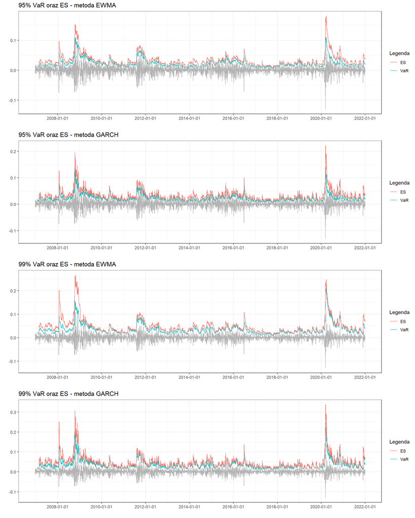

#### WIG

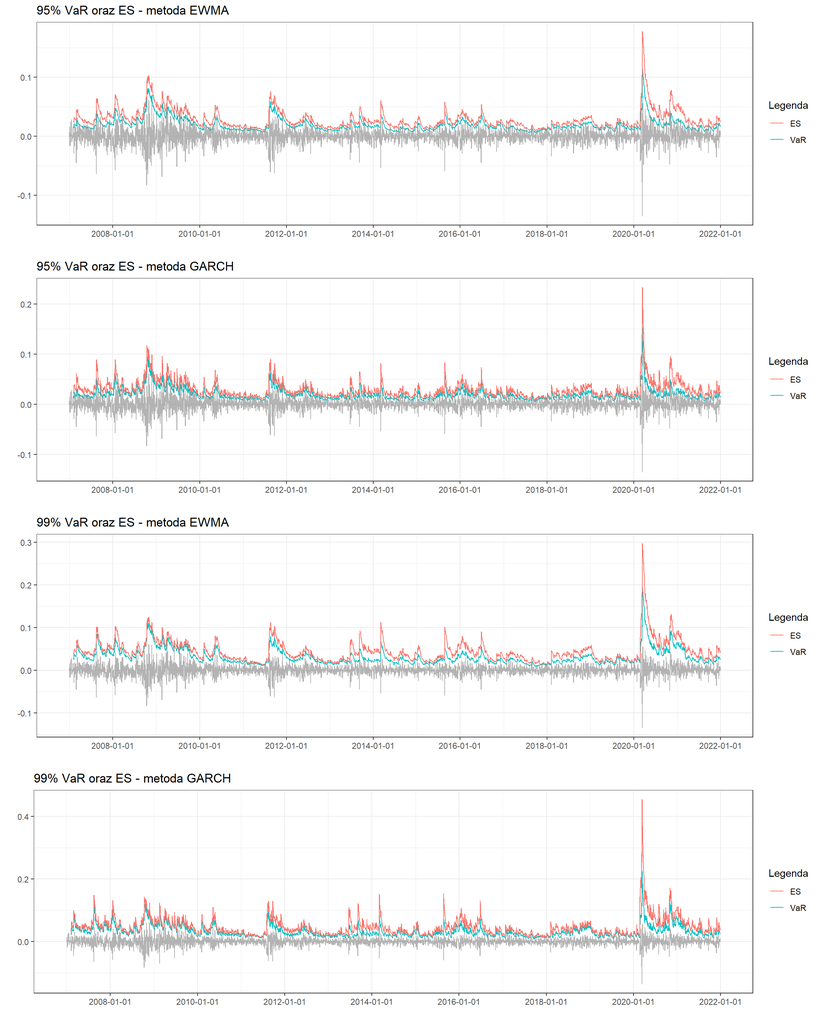

#### SMI

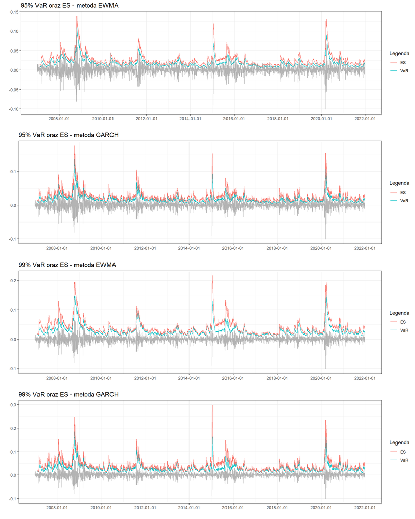

Analizująć powyższe wykresy zauważamy pewne cechy wyznaczonych ciągów VaR w zależności od zastosowanej techniki obliczeń. Zaletą metody historycznej jest jej prostota i łatwość obliczeń. Z drugiej strony VaR szacowane tą techniką słabo dopasowuje się do sytuacji na rynku. Róznice w estymowanym VaR mogą się znacząco różnić, nawet w wyniku pojawienia się jednej dodatkowej obserwacji. Dodatkowo metoda zakłada, że wpływ każdej z obserwacji zawartych w oknie jest taki sam, bez względu na to, czy zdarzenie to miało miejsce wczoraj, czy na początku rozpatrywanego okna.

Pasma VaR i ES wyznaczone za pomocą modeli EWMA i GARCH(1,1) bardzo dynamicznie odpowiadają na zmiany w sytuacji rynkowej i dopasowują sie do zmian historycznych. Widzimy, ze wartość narażona na ryzyko i warunkowa wartość narażona na ryzyko przyjmują odpowiednio większe wartości w okresach, gdy występowały duze wahania stóp zwrotu - tzn. gdy, sytuacja na rynku byla niepewna, a ryzyko było większe.

## 4. Porównanie metod estymacji Value at Risk

Dokonano weryfikacji przydatności poszczególnych modeli do szacowania wartości VaR dla stóp zwrotu szeregów indeksów DAX30, WIG oraz SMI z okresu od stycznia 2006 do grudnia 2021. W poniższej tabeli porównano jakość poszczególnych technik. Przedstawiono procent stóp zwrotu jaki stanowiły przekroczenia dziennej wartości VaR dla poszczególnych indeksów giełdowych, modeli dla poziomu istotności 0,05 oraz 0,01. Przeprowadzono również dwa testy statystyczne - test Kupca, który sprawdza, czy rzeczywista wartość rynkowa stopy zwrotu przekroczyła szacowaną miarę zagrożenia odpowiednią ilość razy (blisko $1-\alpha$) oraz test Christoffersena, który identyfikuje, czy przekroczenia są od siebie niezależne. P-value dla testów zostało przedstawione w tabeli.

#### test Kupca

$$H_0: model\ VaR\ jest\ poprawny$$

$$H_1: model\ VaR\ nie\ jest\ poprawny$$

#### test Christoffersena

$$H_0: przekroczenia\ VaR\ są\ niezależne\ w\ czasie$$

$$H_1: przekroczenia\ VaR\ nie\ są\ niezależne\ w\ czasie$$

| Indeks | Metoda | Poziom ufności | % wyjątków | p-value test Kupca | p-value test Christoffersona |
| --- | --- | --- | --- | --- | --- |
| DAX | sym. historyczna | 0.95 | 4.753 | 0.481 | 0.693 |
| DAX | sym. historyczna | 0.99 | 0.762 | 0.123 | 0.243 |
| DAX | sym. hist. z wagami | 0.95 | 4.175 | 0.016 | 0.054 |
| DAX | sym. hist. z wagami | 0.99 | 0.63 | 0.014 | 0.042 |
| DAX | EWMA | 0.95 | 4.362 | 0.066 | 0.074 |
| DAX | EWMA | 0.99 | 0.793 | 0.184 | 0.326 |
| DAX | GARCH | 0.95 | 4.256 | 0.031 | 0.008 |
| DAX | GARCH | 0.99 | 0.793 | 0.64 | 0.646 |
| WIG | sym. historyczna | 0.95 | 4.957 | 0.871 | 0.647 |
| WIG | sym. historyczna | 0.99 | 0.72 | 0.069 | 0.158 |
| WIG | sym. hist. z wagami | 0.95 | 4.664 | 0.34 | 0.606 |
| WIG | sym. hist. z wagami | 0.99 | 0.506 | 0.001 | 0.003 |
| WIG | EWMA | 0.95 | 4.91 | 0.801 | 0.523 |
| WIG | EWMA | 0.99 | 0.724 | 0.075 | 0.169 |
| WIG | GARCH | 0.95 | 4.83 | 0.631 | 0.16 |
| WIG | GARCH | 0.99 | 0.724 | 0.374 | 0.51 |
| SMI | sym. historyczna | 0.95 | 5.044 | 0.902 | 0.016 |
| SMI | sym. historyczna | 0.99 | 1.009 | 0.957 | 0.702 |
| SMI | sym. hist. z wagami | 0.95 | 4.433 | 0.104 | 0.07 |
| SMI | sym. hist. z wagami | 0.99 | 0.611 | 0.01 | 0.011 |
| SMI | EWMA | 0.95 | 3.528 | 0 | 0 |
| SMI | EWMA | 0.99 | 0.428 | 0 | 0 |
| SMI | GARCH | 0.95 | 4.062 | 0.007 | 0.001 |
| SMI | GARCH | 0.99 | 0.428 | 0 | 0.002 |

Na podstawie uzyskanych wyników można stwierdzić, że dla niemieckiego indeksu gieldowego DAX i obu poziomów istotności dobrze sprawdziło się modelowanie VaR przy pomocy symulacji historycznej oraz modelu EWMA. Testy Kupca i Chrostoffersena nie dały podstaw do odrzucenia hipotezy zerowej. Dla poziomu istotności 0.01 dobrze spisał sie również model GARCH.

W przypadku warszawskiego indeksu WIG i $\alpha=0.95$ wszystkie metody estymacji ryzyka rynkowego przeszły pozytywnie oba testy. Dla $\alpha=0.99$ jedynie symulacja historyczna z wagami odrzuciła hipotezę zerową w obu testach.

Dla szwajcarskiego indeksu SMI i poziomu istotności 0.05 jedynie symulacja historyczna z wagami pozwoliła dobrze wyestymować miary ryzyka. Praktycznie wszystkie pozostałe metody zawyżyły oszacowanie - liczba przekroczeń była mniejsza od oczekiwanej, a przekroczenia VaR okazały się nie być niezależne od siebie. Dla $\alpha=0.99$ obserwujemy podobną sytuację, jednak tutaj jako jedyna sprawdziła się klasyczna metoda symulacji historycznych.